# Bird Safe Philly–Documenting Bird Strikes at Philadelphia Universities

Author

Jasleen Kalsi

Published

April 26, 2025

### Introduction

Each year, 100 million - 1 billion birds in the United States die due to window strikes [1]. The vast majority of these strikes happen during the Spring and Fall migration seasons [2]. Migrating birds mistake glass and reflective surfaces as open air and fly into them, resulting in window strikes [2]. This issue persists in Philadelphia, due to its prime location on a migratory route termed the Atlantic Flyway, shown below in purple:

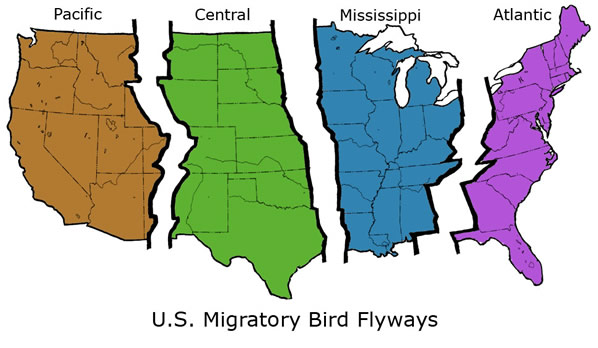

Major Migratory Bird Routes in The United States

An organization named Bird Safe Philly was created in 2020 due to a mass collision event where many migratory birds collided with buildings in Center City, Philadelphia. Since then, people have documented sightings of collisions on [iNaturalists’ Bird Safe Philly](https://inaturalist.ca/projects/bird-safe-philly-bird-strikes-project) project, where the collision data from this project was taken [4].

### Aim

This project illustrates the occurrence of bird strikes throughout the city of Philadelphia. The species of birds colliding with Philadelphia universities will be examined, and the number of birds that are colliding with specific buildings on Temple University’s campus will be investigated. The map of Temple campus boundary as well as the buildings were taken from the [Temple Open Data All Acreage dataset [6].](https://gis-temple.opendata.arcgis.com/datasets/c56e37eaabc64cd1b484b75ab71c95b1_0/explore?location=7.220496%2C-8.031721%2C1.91)

### Map of Bird Strikes in Philadelphia

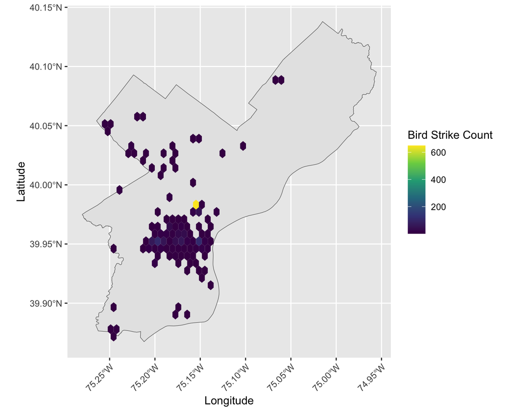

Figure 1: Hexbin map showing the spatial distribution and density of bird strike observations recorded within Philadelphia. Each hexagon represents an area where observations were made, with lighter colors indicating higher concentrations of collisions.

### Species Distribution of Bird Strikes

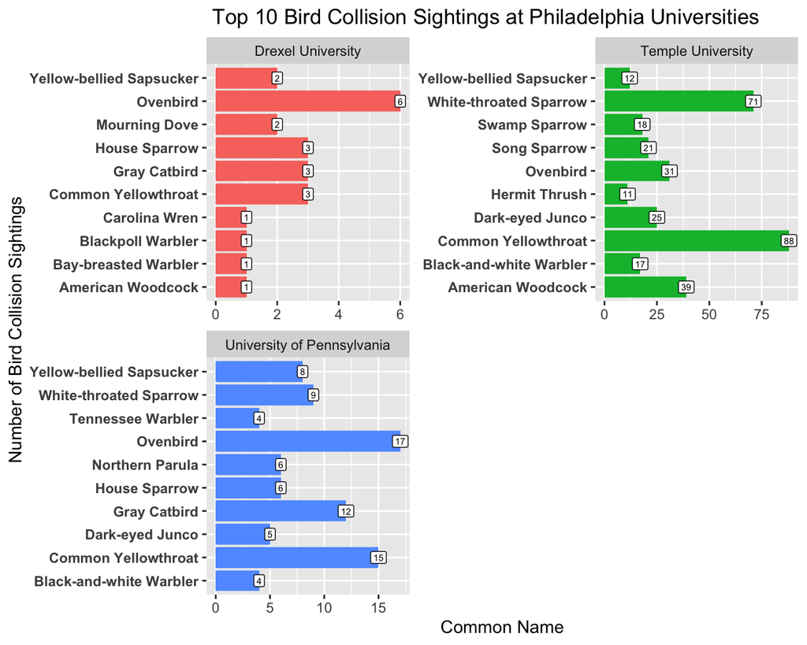

Figure 2: The chart displays the most frequently reported collision species at each campus, based on iNaturalist observations. Note that data collection periods vary by university, which may affect the comparison of bird collision numbers between campuses.

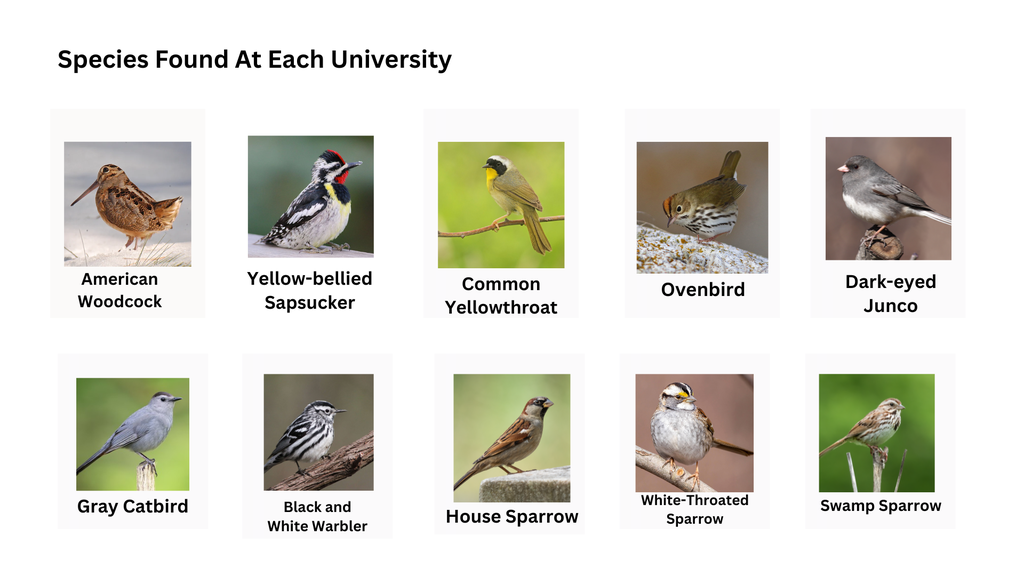

### A Closer Look at Temple University’s Bird Strikes

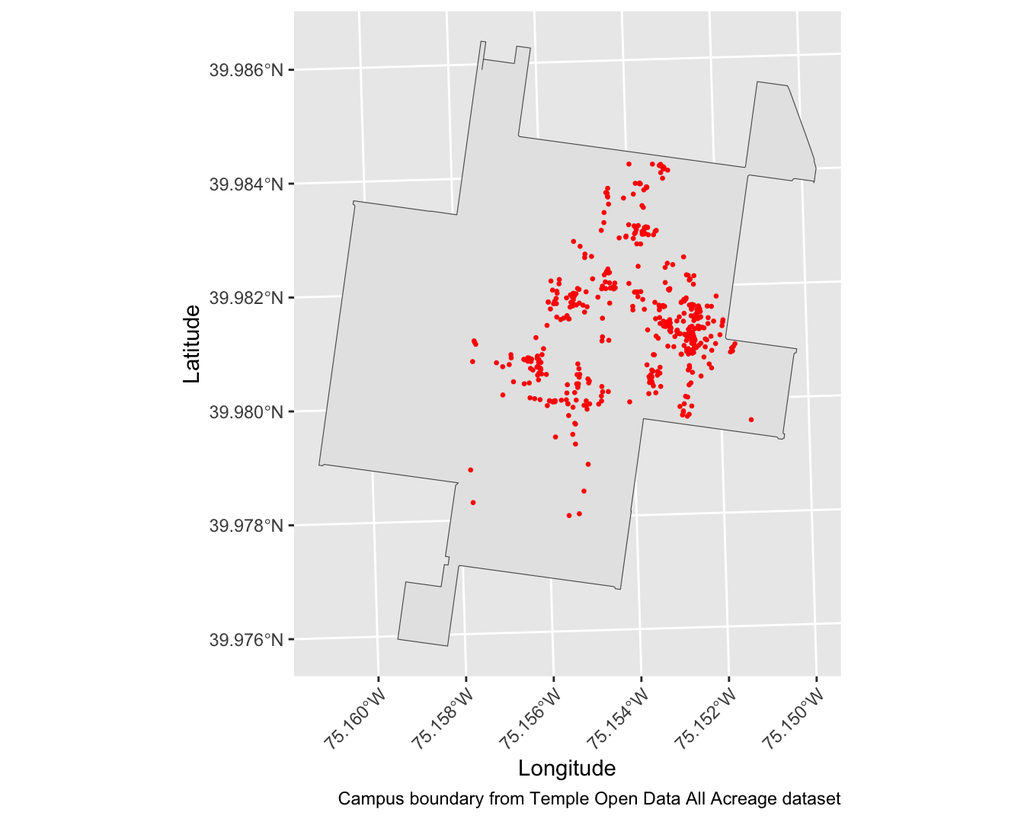

Figure 3: Map of Reported Bird-Window Collisions on Temple University’s Main Campus. Each point represents the location of an observed bird strike, highlighting areas where collisions have been reported.

#### Bird Strikes Per Building on Main Campus

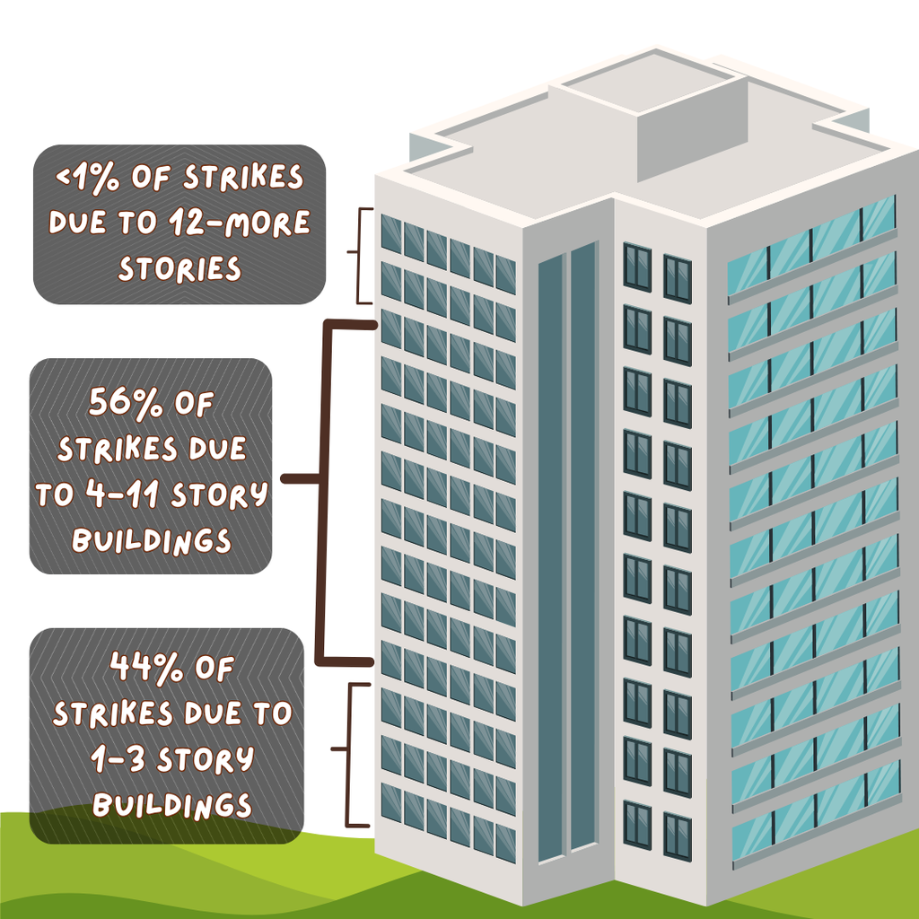

Breakdown of Collisions on Building Heights

In his book *Solid Air: Invisible Killer – Saving Billions of Birds from Windows*, ornithologist Daniel Klem discusses how bird collisions with windows vary across buildings of different heights.

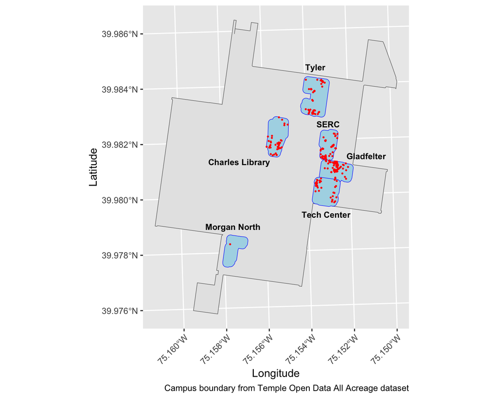

Figure 4: This map displays the locations of buildings where bird collisions have occurred, with points representing bird strikes within a 50-foot buffer zone around select buildings on campus.

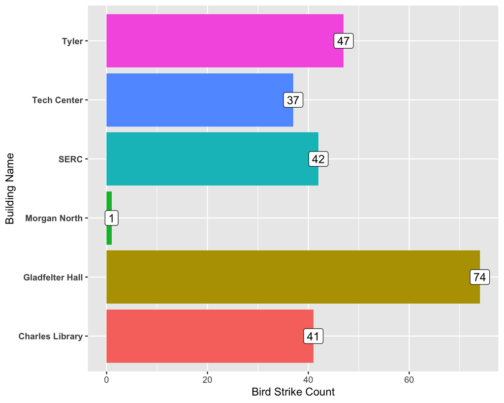

Figure 5: Number of Bird Collisions Within a 50-Foot Buffer Around Select Buildings on Temple University’s Main Campus. This bar graph shows the total number of reported bird-window collisions that occurred within a 50-foot radius of specific campus buildings, highlighting which buildings experienced the highest strike counts.

## Conclusions

[Figure 1](https://tup13036-collab.github.io/Temple-Bird-Collision-/Kalsi_S25_final_project_%20SUBMITTED.html#fig-mapofbirdstrikes) was made to show where the highest concentration of bird strikes have been reported in Philadelphia. While many strikes have been reported in the Center City area, the highest concentration was shown to be near Temple University in yellow, which is why the university was chosen for further analysis. Many universities have begun reporting bird strike incidents alongside Temple University, including the University of Pennsylvania and Drexel University. The location of the collision and the species are reported as shown in [Figure 2](https://tup13036-collab.github.io/Temple-Bird-Collision-/Kalsi_S25_final_project_%20SUBMITTED.html#fig-speciesdistribution) on iNaturalist. Overall, mainly the same species are found at each campus. Out of each university, Temple University has the most bird strikes counts, which is most likely due to a bigger sampling effort compared to other campuses. For this reason, [Figure 3](https://tup13036-collab.github.io/Temple-Bird-Collision-/Kalsi_S25_final_project_%20SUBMITTED.html#fig-templestrikemap) and [Figure 4](https://tup13036-collab.github.io/Temple-Bird-Collision-/Kalsi_S25_final_project_%20SUBMITTED.html#fig-birdstrikebuildings) were made to show the locations of bird strikes on Temple Main Campus, and the strikes appearing around certain buildings. In [Figure 5](https://tup13036-collab.github.io/Temple-Bird-Collision-/Kalsi_S25_final_project_%20SUBMITTED.html#fig-birdstrikecount), Gladfelter Hall had the most bird strikes in a 50-foot radius, compared to the other buildings. It’s important to note that although the buildings in [Figure 4](https://tup13036-collab.github.io/Temple-Bird-Collision-/Kalsi_S25_final_project_%20SUBMITTED.html#fig-birdstrikebuildings) and [Figure 5](https://tup13036-collab.github.io/Temple-Bird-Collision-/Kalsi_S25_final_project_%20SUBMITTED.html#fig-birdstrikecount) have varying heights, the materials they’re made with (glass, brick, etc) as well as the greenery around them influence the number of bird strikes that occur [3].

This information is useful to have to determine which buildings are observed to have the most strikes, and which buildings may need more surveying. For example, Morgan North is a 27-story building, the tallest of all of the buildings in [Figure 4](https://tup13036-collab.github.io/Temple-Bird-Collision-/Kalsi_S25_final_project_%20SUBMITTED.html#fig-birdstrikebuildings), and there has only been one bird strike observed within a 50-foot radius since sampling began [5]. This could be due to sampling not being done as frequently on that side of campus, or clean up is more efficient around the building than near the hot spot buildings such as SERC, Gladfelter Hall, and the Tech Center. For the hot spot collision area on campus, evaluations of the percentage of glass cover on each building can be done to see if that is causing an increase of bird strikes on those buildings. Furthermore, these findings can be presented to the lead architect on Temple Main Campus, and bird-friendly glass can be proposed as mitigation strategies for buildings such as SERC, Gladfelter, and the Tech Center where many collisions have been reported.

Lastly, future directions for this project are to add more buildings to the campus boundary map to determine their collision counts. The frequency of bird strikes, and the time of year and time of day they occur can be investigated further as well.

## Acknowledgements

A huge thanks to all the volunteers at Temple University who have dedicated countless hours collecting bird collision data and saving stunned birds! Special thanks to Dr. Maria Pacheco, Mandy Gibson, Violet Lange, Christy Davids, Marc Getty, and Rylie Kelley. If you would like to get involved and/or learn more about their work, go to https://sites.temple.edu/bird/.

## References

[1] Klem, D. Jr. (2021). Solid air: Invisible killer—Saving billions of birds from windows. Hancock House Publishers.

[2] Basilio, L. G., Moreno, D. J., & Piratelli, A. J. (2020). Main causes of bird-window collisions: a review. *Anais da Academia Brasileira de Ciências*, *92*, e20180745.

[3] Daniel Klem, Jr. (1989). Bird: Window Collisions. *The Wilson Bulletin*, *101*(4), 606–620. http://www.jstor.org/stable/4162790

[4] iNaturalist Canada. (2021). Bird Safe Philly Bird Strikes Project [Community science project]. Retrieved from https://inaturalist.ca/projects/bird-safe-philly-bird-strikes-project

[5] SkyscraperCenter. Temple University Morgan Hall North [Building information]. Retrieved from https://www.skyscrapercenter.com/building/temple-university-morgan-hall-north/28955.

[6] Temple University. (2018). TU Campus Boundary [Geospatial dataset]. Retrieved from https://gis-temple.opendata.arcgis.com/datasets/c56e37eaabc64cd1b484b75ab71c95b1_0/explore?location=1.077567%2C-8.031721%2C1.91